# Plotting data with Seaborn

1. What is Seaborn?
2. Scatter plots
3. Line plots
4. Plotting categorical data
5. Facetting
6. Customising labels
7. Customising the look of your plot with styles
8. Finishing touches and saving plots

## What is Seaborn?

Python's most well-known package for creating plots is called `matplotlib`. `seaborn` is a Python package that has a slightly friendlier syntax (more similar to that of `ggplot2` in R), that calls `matplotlib` in the background. We'll start by importing the `pandas` and `seaborn` packages, and also importing just the `pyplot` module of `matplotlib` (so we can save our plots later on). `seaborn` comes with some datasets built in, so we load in the `penguins` dataset that contains observations taken from penguins in Antarctica.

```python
import pandas as pd
import seaborn as sns
import matplotlib.pyplot as plt

penguins = sns.load_dataset('penguins')
penguins
```

|  | species | island | bill_length_mm | bill_depth_mm | flipper_length_mm | body_mass_g | sex |
| --- | --- | --- | --- | --- | --- | --- | --- |
| 0 | Adelie | Torgersen | 39.1 | 18.7 | 181.0 | 3750.0 | Male |
| 1 | Adelie | Torgersen | 39.5 | 17.4 | 186.0 | 3800.0 | Female |
| 2 | Adelie | Torgersen | 40.3 | 18.0 | 195.0 | 3250.0 | Female |
| 3 | Adelie | Torgersen | NaN | NaN | NaN | NaN | NaN |
| 4 | Adelie | Torgersen | 36.7 | 19.3 | 193.0 | 3450.0 | Female |
| ... | ... | ... | ... | ... | ... | ... | ... |
| 339 | Gentoo | Biscoe | NaN | NaN | NaN | NaN | NaN |
| 340 | Gentoo | Biscoe | 46.8 | 14.3 | 215.0 | 4850.0 | Female |
| 341 | Gentoo | Biscoe | 50.4 | 15.7 | 222.0 | 5750.0 | Male |
| 342 | Gentoo | Biscoe | 45.2 | 14.8 | 212.0 | 5200.0 | Female |
| 343 | Gentoo | Biscoe | 49.9 | 16.1 | 213.0 | 5400.0 | Male |

344 rows × 7 columns

## Scatter plots

We can quickly generate some nice scatter plots using `seaborn`'s `relplot()` function (for "relationship plot"). We give the `data`, `x`, `y`, and `hue` arguments (hue being the variable we want mapped to the colour). We automatically get the legend created for us.

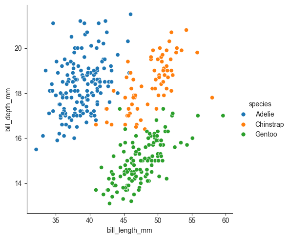

```python
sns.relplot(
    data = penguins,
    x    = 'bill_length_mm',
    y    = 'bill_depth_mm',
    hue  = 'species'
)
```

We can map a variable to the size of the points.

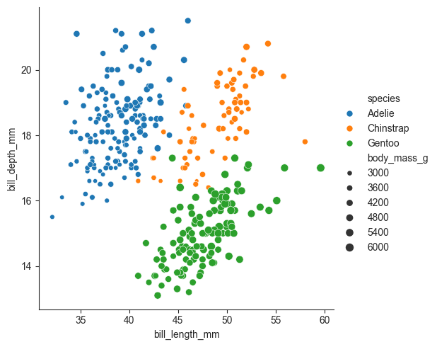

```python
sns.relplot(
    data = penguins,
    x    = 'bill_length_mm',
    y    = 'bill_depth_mm',
    hue  = 'species',
    size = 'body_mass_g'
)
```

Or to the *style* (shape) of the points.

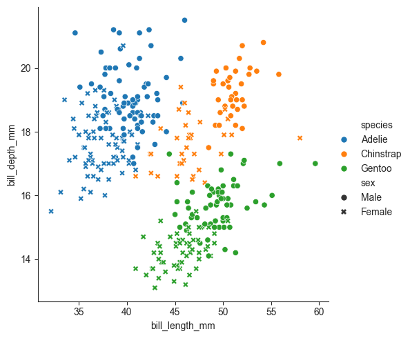

```python
sns.relplot(
    data  = penguins,
    x     = 'bill_length_mm',
    y     = 'bill_depth_mm',
    hue   = 'species',
    style = 'sex'
)
```

If we want to include plots of the marginal distributions of each variable, we can use the `jointplot()` function, giving the same arguments as before. Play around with the `space` argument to see its effect.

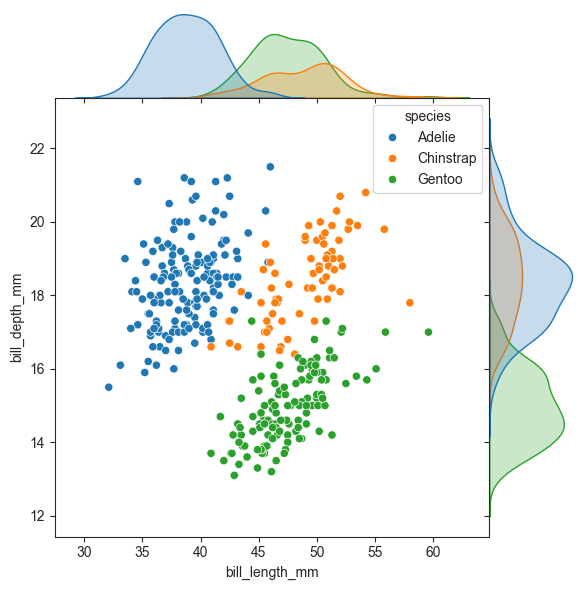

```python
sns.jointplot(
    data = penguins,
    x    = "bill_length_mm",
    y    = "bill_depth_mm",
    hue  = "species",
    space = 0
    )
```

We can overlay contour lines onto this plot if we like using the `plot_joint()` method. Experiment with the `bw_adjust` argument (default is 1).

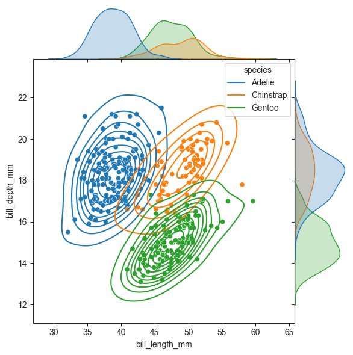

```python
p1 = sns.jointplot(
    data = penguins,
    x    = 'bill_length_mm',
    y    = 'bill_depth_mm',
    hue  = 'species',
    space = 0
)

p1.plot_joint(sns.kdeplot, bw_adjust = 1.5)
```

If we want a quick visualisation of all pairwise relationships, we can use the `pairplot()` function (careful if you have many veriables).

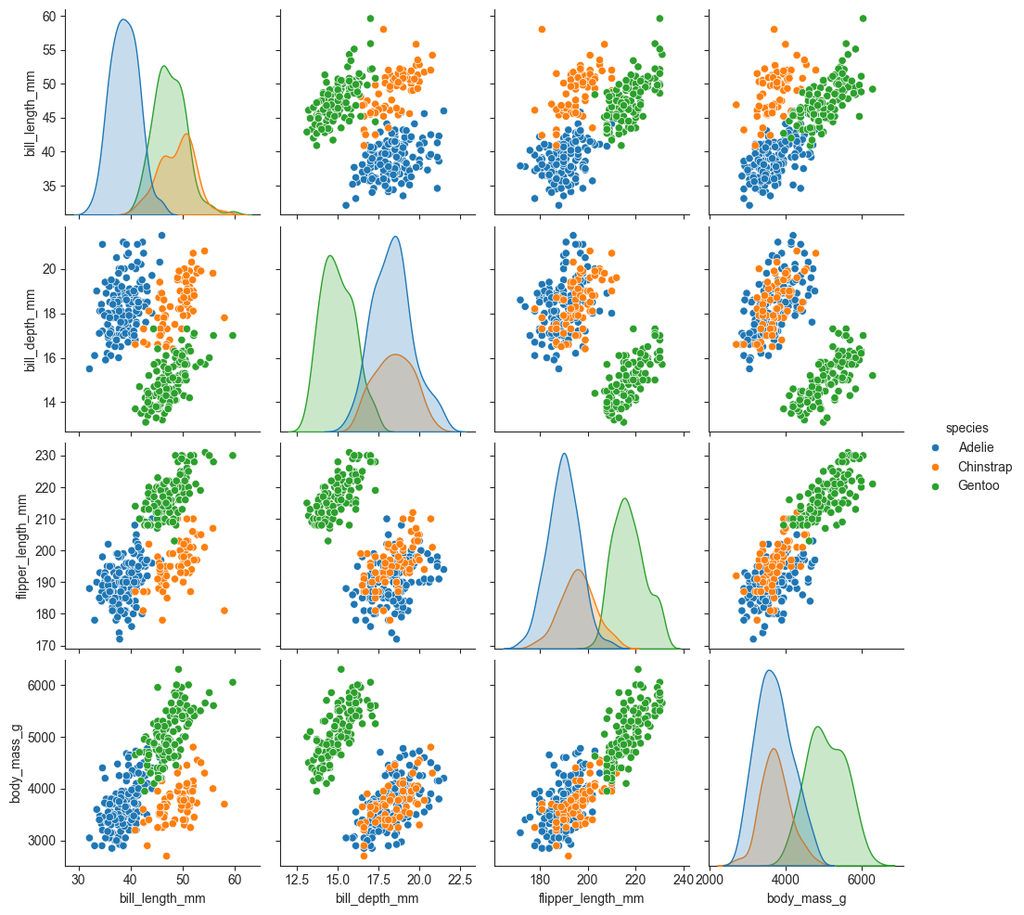

```python
sns.pairplot(data=penguins, hue = "species")
```

## Line plots

When wanting to represent how a quantity changes over time, we will often employ line graphs. As our penguins dataset doesn’t lend itself to this kind of plotting, we’re going to load a new dataset with the numbers of passengers by month and year (I can't find a proper description of this dataset so can't say more than that).

```python
flights = sns.load_dataset('flights')
flights
```

|  | year | month | passengers |
| --- | --- | --- | --- |
| 0 | 1949 | Jan | 112 |
| 1 | 1949 | Feb | 118 |
| 2 | 1949 | Mar | 132 |
| 3 | 1949 | Apr | 129 |
| 4 | 1949 | May | 121 |
| ... | ... | ... | ... |
| 139 | 1960 | Aug | 606 |
| 140 | 1960 | Sep | 508 |
| 141 | 1960 | Oct | 461 |
| 142 | 1960 | Nov | 390 |
| 143 | 1960 | Dec | 432 |

144 rows × 3 columns

We can plot this data using our familiar `relplot()` function, but setting `kind = 'line'`. This draws a line between each observation, with a different line per year.

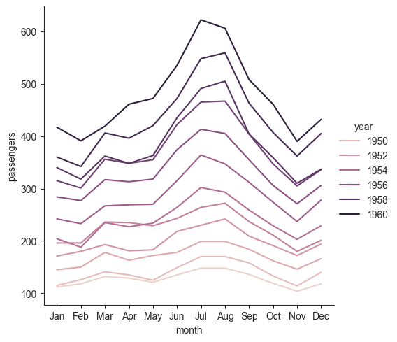

```python
sns.relplot(
    data = flights,
    x    = 'month',
    y    = 'passengers',
    hue  = 'year',
    kind = 'line'
)
```

If we want to draw the individual points as well, we can set `marker = 'o'` (or another [marker shape](https://seaborn.pydata.org/tutorial/properties.html)).

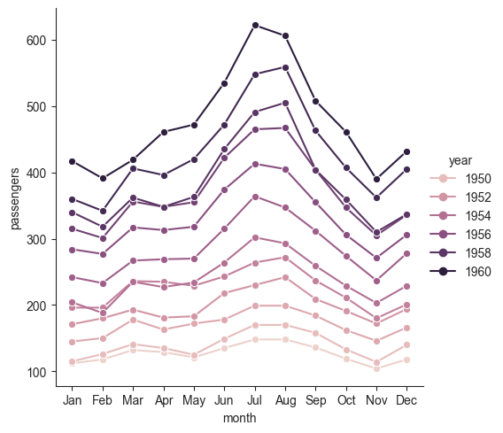

```python
sns.relplot(
    data = flights,
    x    = 'month',
    y    = 'passengers',
    hue  = 'year',
    kind = 'line',
    marker = 'o'
)
```

If we want a smooth polynomial through each year's data points instead, we first extract the months as integers, then use `lmplot` ("linear model plot"), adjusting the `order` of the polynomial depending on how "wiggly" we want our smooths to be. I also use `ci = None` to suppress confidence intervals.

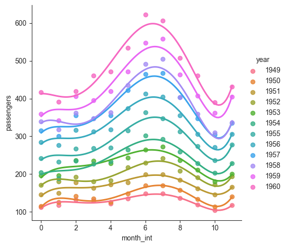

```python
flights['month_int'] = pd.Categorical(flights.month).codes

sns.lmplot(
    data  = flights,
    x     = 'month_int',
    y     = 'passengers',
    hue   = 'year',
    order = 5,
    ci    = None
)
```

We can do something similar if we want separate regression lines drawn per group.

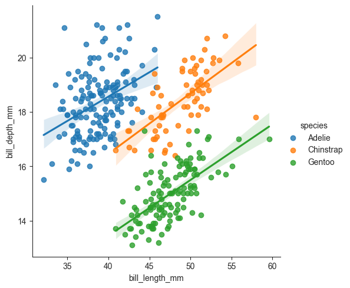

```python
sns.lmplot(
    data  = penguins,
    x     = 'bill_length_mm',
    y     = 'bill_depth_mm',
    hue   = 'species',
    ci    = 95,
    order = 1
)
```

## Plotting categorical data

When plotting a categorical variable against a continuous one, we often make use of bar plots, boxplots, and violin plots.

Let’s start by creating a bar chart to show the frequency of each penguin species using `catplot()` (for "categorical plot"), by setting `kind = 'count'`.

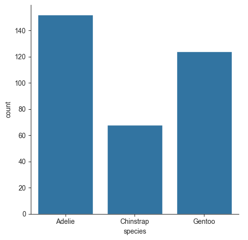

```python
sns.catplot(data = penguins, x = 'species', kind = 'count')
```

If we want to plot a categorical variable against a continuous one, we still use `catplot()` but provide `x` *and* `y` arguments, and omit the `kind` argument.

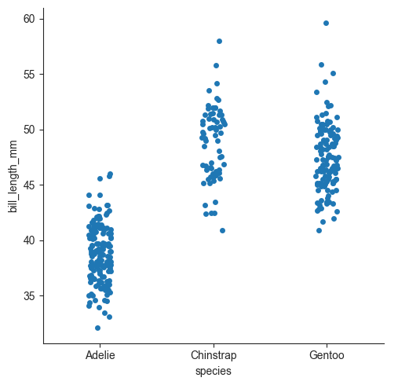

```python
sns.catplot(data = penguins, x = 'species', y = 'bill_length_mm')
```

By default the points are "jittered" horizontally to reduce overplotting, but we can turn this off by setting `jitter = False`.

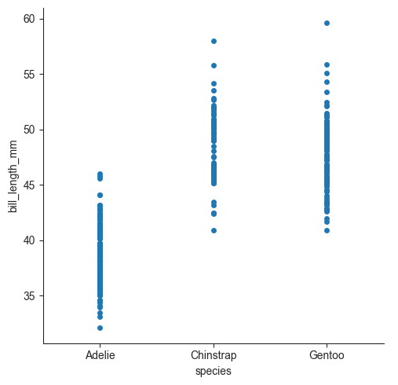

```python
sns.catplot(data = penguins, x = 'species', y = 'bill_length_mm', jitter = False)
```

We can also set `kind = 'swarm'` to get a swarm plot where points are jittered horizontally to avoid overlaps.

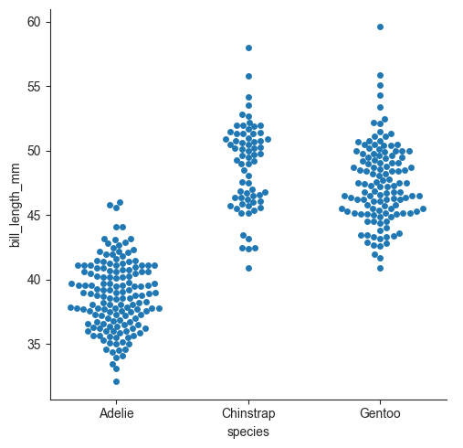

```python
sns.catplot(data = penguins, x = 'species', y = 'bill_length_mm', kind = 'swarm')
```

We can still map variables to the `hue` argument.

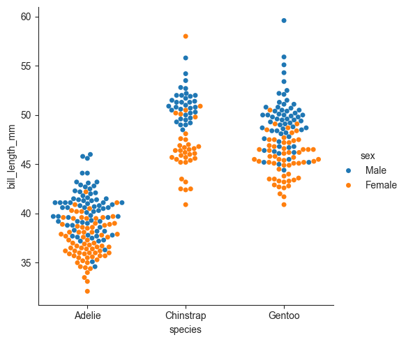

```python
sns.catplot(
    data = penguins,
    x    = 'species',
    y    = 'bill_length_mm',
    hue  = 'sex',
    kind = 'swarm'
    )
```

There's no rule that says the categorical variable must be on the x axis. Sometimes, it's even better to have it mapped to the y axis. If we want the categorical variable to appear in a specific order, we simply give a list of the categories in our desired order to the `order` argument.

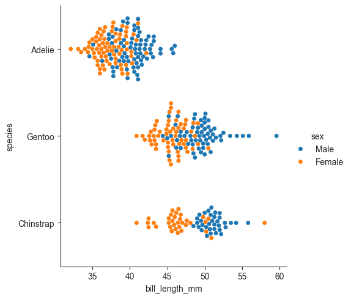

```python
sns.catplot(
    data = penguins,
    x    = 'bill_length_mm',
    y    = 'species',
    hue  = 'sex',
    kind = 'swarm',
    order = ['Adelie', 'Gentoo', 'Chinstrap']
    )
```

We can create a boxplot by setting `kind = 'box'`, and the boxes are automatically "dodged" side-by-side for us.

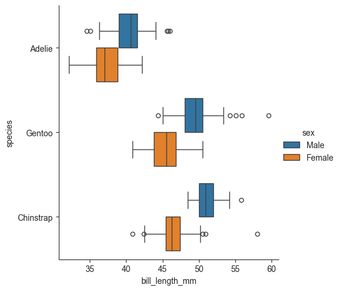

```python
sns.catplot(
    data = penguins,
    x    = 'bill_length_mm',
    y    = 'species',
    hue  = 'sex',
    kind = 'box',
    order = ['Adelie', 'Gentoo', 'Chinstrap']
    )
```

Similar to a boxplot, you can create a violin plot to show the distribution of points for each group by setting `kind = 'violin'`.

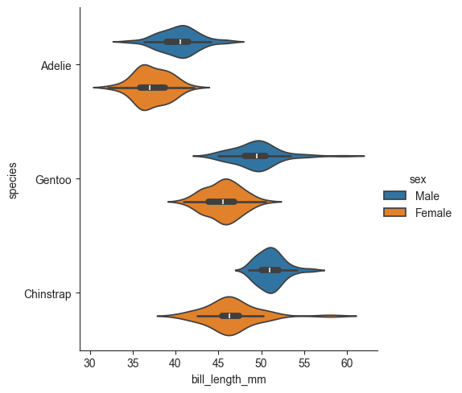

```python
sns.catplot(
    data = penguins,
    x    = 'bill_length_mm',
    y    = 'species',
    hue  = 'sex',
    kind = 'violin',
    order = ['Adelie', 'Gentoo', 'Chinstrap']
    )
```

By default, we get completely separate "violins" for our categorical variables, but if we set `split = True`, we get the top and bottom half of each violin mapped to our `hue` variable.

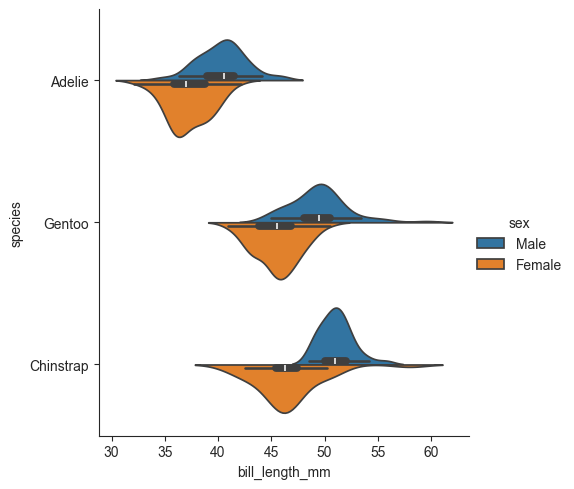

```python
sns.catplot(
    data = penguins,
    x    = 'bill_length_mm',
    y    = 'species',
    hue  = 'sex',
    kind = 'violin',
    split = True,
    order = ['Adelie', 'Gentoo', 'Chinstrap']
    )
```

If we want to represent the data with a bar plot with error bars, we can set `kind = 'bar'`. By default the `estimator` is the mean but you can give another function to this. Here, I've chosen to represent 1 standard deviation with the error bars. It’s bad practice to show only summary statistics, and showing the raw points along with the mean bars is better but it isn't clear to me how to achieve this with `seaborn`.

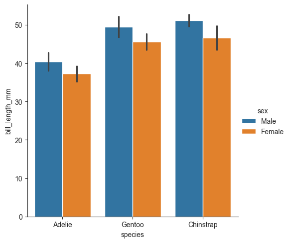

```python
sns.catplot(
    data      = penguins,
    x         = 'species',
    y         = 'bill_length_mm',
    hue       = 'sex',
    kind      = 'bar',
    estimator = 'mean',
    errorbar  = ('sd', 1),
    order     = ['Adelie', 'Gentoo', 'Chinstrap']
    )
```

## Facetting

When we have multiple variables we wish to represent in a plot, we can create clearer, more effective visualisations by splitting the data across subplots, or facets. In `seaborn` this is controlled with the `col` argument that, perhaps confusingly, doesn't control colour but controls which variable is mapped to different *columns* of plots.

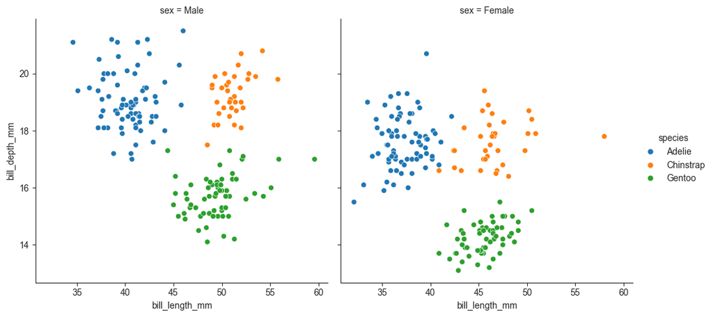

```python
sns.relplot(
    data = penguins,
    x    = 'bill_length_mm',
    y    = 'bill_depth_mm',
    hue  = 'species',
    col  = 'sex'
)
```

We can control the number of rows and columns by setting the `col_wrap` argument to the number of columns of facets we wish to get.

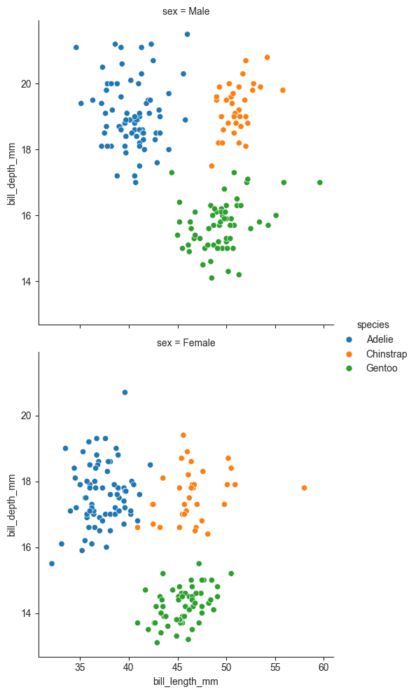

```python
sns.relplot(
    data     = penguins,
    x        = 'bill_length_mm',
    y        = 'bill_depth_mm',
    hue      = 'species',
    col      = 'sex',
    col_wrap = 1
)
```

We can map specific variables to the rows and columns of a grid by first defining a grid with `FacetGrid()`, defining which variables we want to be mapped to the rows and columns (and any other mappings like `hue`). Then, we use the `map()` method to set our `x` and `y` variable mappings.

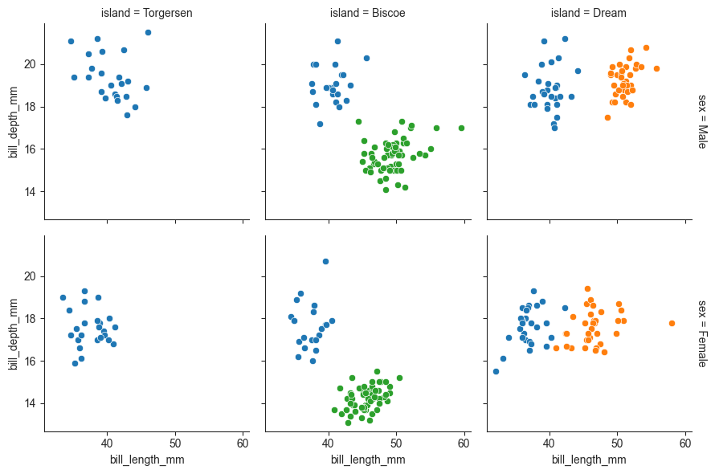

```python
g = sns.FacetGrid(
    penguins,
    row           = 'sex',
    col           = 'island',
    hue           = 'species',
    margin_titles = True
)

g.map(sns.scatterplot, 'bill_length_mm', 'bill_depth_mm')
```

## Customising labels

If we want to share our plot with others in a report or publication, we’ll probably want it to have a nice title and labels. We can add a title and axis labels by using the `set()` method. If we want to change or remove the legend title, we need to use the `_legend.set()` method.

```
[None]
```

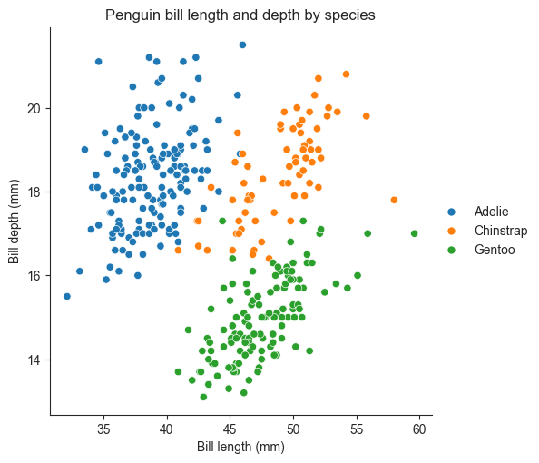

```python
p2 = sns.relplot(
    data = penguins,
    x    = 'bill_length_mm',
    y    = 'bill_depth_mm',
    hue  = 'species'
)

p2.set(
    xlabel = 'Bill length (mm)',
    ylabel = 'Bill depth (mm)',
    title  = 'Penguin bill length and depth by species'
)

p2._legend.set(title = '')
```

## Customising the look of your plot with styles

You can customise each feature of your plots as you like, but a good place to start is using one of `seaborn`'s built-in styles using the `set_style()` function.

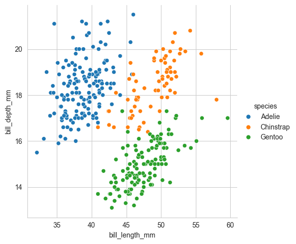

```python
sns.set_style('whitegrid')

sns.relplot(
    data = penguins,
    x    = 'bill_length_mm',
    y    = 'bill_depth_mm',
    hue  = 'species'
)
```

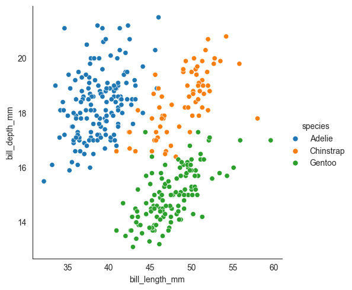

```python
sns.set_style('white')

sns.relplot(
    data = penguins,
    x    = 'bill_length_mm',
    y    = 'bill_depth_mm',
    hue  = 'species'
)
```

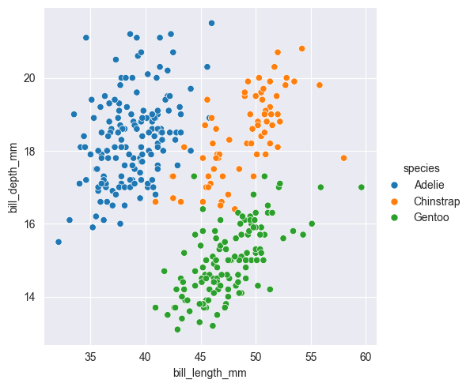

```python
sns.set_style('darkgrid')

sns.relplot(
    data = penguins,
    x    = 'bill_length_mm',
    y    = 'bill_depth_mm',
    hue  = 'species'
)
```

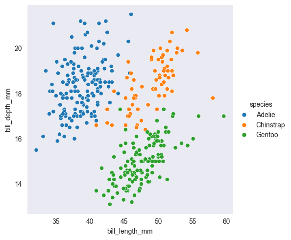

```python
sns.set_style('dark')

sns.relplot(
    data = penguins,
    x    = 'bill_length_mm',
    y    = 'bill_depth_mm',
    hue  = 'species'
)
```

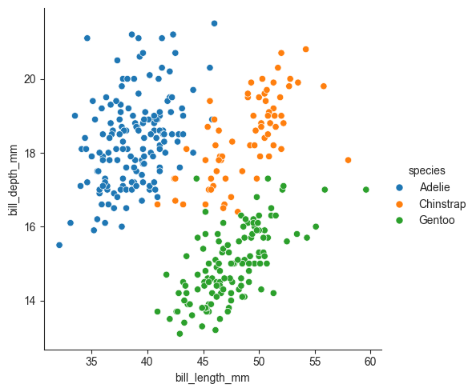

```python
sns.set_style('ticks')

sns.relplot(
    data = penguins,
    x    = 'bill_length_mm',
    y    = 'bill_depth_mm',
    hue  = 'species'
)
```

## Finishing touches and saving plots

We can control the colour palette by setting `palette` to [one of `seaborn`'s built-in colour palettes](https://seaborn.pydata.org/tutorial/color_palettes.html). We can use the `despine()` method to offset the axes if we wish, and the `set()` method to set labels and axis limits. We use the `move_legend()` function to place the legend where we want it, including `frameon = True` to draw its border.

Finally, we use `savefig()` (from the matplotlib.pyplot module) to write the image out as a file, setting `bbox_inches = 'tight'` to ensure no plot components get clipped. The function infers the image format from the file extension and can be one of eps, 'jpeg', 'jpg', 'pdf', 'pgf', 'png', 'ps', 'raw', 'rgba', 'svg', 'svgz', 'tif', 'tiff', or 'webp'.

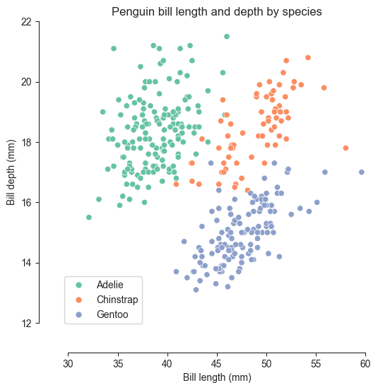

```python
p3 = sns.relplot(
    data    = penguins,
    x       = 'bill_length_mm',
    y       = 'bill_depth_mm',
    hue     = 'species',
    palette = 'Set2'
)

p3.despine(offset = 30, trim = False)

p3.set(
    xlabel = 'Bill length (mm)',
    ylabel = 'Bill depth (mm)',
    title  = 'Penguin bill length and depth by species',
    ylim   = (12, 22),
    xlim   = (30, 60)
)

p3._legend.set(title = '')

sns.move_legend(p3, 'lower left', bbox_to_anchor = (.1, .1), frameon = True)

plt.savefig('plots/penguin_plot.png', dpi = 300, bbox_inches = "tight")
```